# Customer Segmentation & Market Basket Analysis in Online Retail

Maria Pilar Bifaretti

2023

### THE DATASET & GOAL OF THE ANALYSIS

The world of online retail opens up vast opportunities for businesses to understand and cater to their customers’ diverse needs. In my quest for insights, I used the Online Retail II dataset, made available by the UC Irvine Machine Learning Repository. It encapsulates the purchases made by registered customers of a non-store online retailer, spanning the period from 01/12/2009 to 09/12/2011.

Within this data set lie 1,067,371 entries accompanied by 8 columns. Let’s delve into the depths of this data set and explore its essence:

1. InvoiceNo: A unique 6-digit integral number assigned to each transaction. Some transactions bear the mark of cancellation, designated by the letter ‘c.’
2. StockCode: A 5-digit integer that serves as the identifier to each distinct product
3. Description: The product name that serves as description of what was bought.
4. Quantity: A numeric field with the quantities of each product in the shopping carts of customers.
5. InvoiceDate: Numeric field with the day and time when a transaction was generated.
6. UnitPrice: Numeric field containing the price per unit of the product, denoted in sterling.
7. CustomerID: A 5-digit integral number assigned to each customer, allowing for individual customer identification.
8. Country: The name of the country where each customer resides, categorized as a nominal attribute.

**The *goal of the analysis* encompasses two key aspects: cluster analysis and market basket analysis.**

- Cluster Analysis: The aim is to segment customers into distinct clusters based similarities in their purchasing behavior. By identifying meaningful clusters, we can better understand customer segments and tailor the retailer strategies to meet their specific needs. This analysis helps strike a balance between personalized service and a consistent product offering.
- Market Basket Analysis: Exploring patterns of item associations within customer transactions. Market basket analysis uncovers frequently co-occurring products, enabling us to identify product affinities and make informed recommendations. This analysis provides valuable insights for cross-selling, inventory management, and personalized marketing initiatives.

Through the combined power of cluster analysis and market basket analysis, the ultimate goal is to have comprehensive insights into customer behavior, enhance business decision-making, and unlock opportunities for strategic growth in the dynamic realm of online retail.

### LIBRARIES

For the analysis, we will be utilizing the following *R packages:*

```r
library(dplyr)
library(lubridate)
```

```r
library(DT)
library(ggplot2)
library(ggthemes)
library(gridExtra)
library(grid)
library(cluster)
library(psych)
library(fmsb)
library(pdftools)
library(magick)
library(arules)
library(arulesViz)
```

### DATACLEANING

Let’s begin by importing the CSV file and exploring the data set:

```r
#Import the csv file
retail <- read.csv("online_retail_II.csv")

# Get an overview of the dataset structure
str(retail)
```

```
## 'data.frame':    1067371 obs. of  8 variables:
##  $ Invoice    : chr  "489434" "489434" "489434" "489434" ...
##  $ StockCode  : chr  "85048" "79323P" "79323W" "22041" ...
##  $ Description: chr  "15CM CHRISTMAS GLASS BALL 20 LIGHTS" "PINK CHERRY LIGHTS" " WHITE CHERRY LIGHTS" "RECORD FRAME 7\" SINGLE SIZE " ...
##  $ Quantity   : int  12 12 12 48 24 24 24 10 12 12 ...
##  $ InvoiceDate: chr  "2009-12-01 07:45:00" "2009-12-01 07:45:00" "2009-12-01 07:45:00" "2009-12-01 07:45:00" ...
##  $ Price      : num  6.95 6.75 6.75 2.1 1.25 1.65 1.25 5.95 2.55 3.75 ...
##  $ Customer.ID: num  13085 13085 13085 13085 13085 ...
##  $ Country    : chr  "United Kingdom" "United Kingdom" "United Kingdom" "United Kingdom" ...
```

The data set consists of **8 variables**, and we have **1,067,371 customer records.**

```r
head(retail)
```

```
##   Invoice StockCode                         Description Quantity
## 1  489434     85048 15CM CHRISTMAS GLASS BALL 20 LIGHTS       12
## 2  489434    79323P                  PINK CHERRY LIGHTS       12
## 3  489434    79323W                 WHITE CHERRY LIGHTS       12
## 4  489434     22041        RECORD FRAME 7" SINGLE SIZE        48
## 5  489434     21232      STRAWBERRY CERAMIC TRINKET BOX       24
## 6  489434     22064          PINK DOUGHNUT TRINKET POT        24
##           InvoiceDate Price Customer.ID        Country
## 1 2009-12-01 07:45:00  6.95       13085 United Kingdom
## 2 2009-12-01 07:45:00  6.75       13085 United Kingdom
## 3 2009-12-01 07:45:00  6.75       13085 United Kingdom
## 4 2009-12-01 07:45:00  2.10       13085 United Kingdom
## 5 2009-12-01 07:45:00  1.25       13085 United Kingdom
## 6 2009-12-01 07:45:00  1.65       13085 United Kingdom
```

#### Null values & Duplicates

Moving on to data cleaning, let’s assess missing and null values in the data set:

```r
# Check for missing values
colSums(is.na(retail))
```

```
##     Invoice   StockCode Description    Quantity InvoiceDate       Price
##           0           0           0           0           0           0
## Customer.ID     Country
##      243007           0
```

The result shows that there are **243,007 missing values in the Customer.ID attribute.** As this attribute serves as our unique customer identifier, it is necessary to remove rows with missing Customer IDs.

```r
# Remove rows with missing Customer IDs
retail <- retail[!is.na(retail$Customer.ID), ]

# Check for null values
any(is.null(retail))
```

```
## [1] FALSE
```

Good news! There are **no null values** in the data set.

Now, let’s explore and **remove duplicates**, if any, to ensure data integrity:

```r
# Find duplicated rows based on all 8 attributes
duplicated_rows <- duplicated(retail)

# Display the duplicated rows
duplicated_data <- retail[duplicated_rows, ]

# Remove duplicate rows based on all 8 attributes
retail <- unique(retail)

# Verify the updated data set
dim(retail)  # Check the dimensions of the updated data set
```

```
## [1] 797885      8
```

Following the removal of duplicate rows, the dataset now contains *797,885 observations.*

#### Date and Time

Next, we’ll extract valuable insights by splitting the *‘InvoiceDate’* attribute into two separate columns:

```r
# Convert "InvoiceDate" column to POSIXct format
retail$InvoiceDate <- ymd_hms(retail$InvoiceDate)

# Create new columns for date and time
retail$Date <- as.Date(retail$InvoiceDate)
retail$Time <- format(retail$InvoiceDate, format = "%H:%M:%S")

# Convert Time column to POSIXct format
retail$Time <- as.POSIXct(retail$Time, format = "%H:%M:%S")

# Remove the original "InvoiceDate" column
retail <- retail %>%
  select(-InvoiceDate)

#Check results
head(retail, 3)
```

```
##   Invoice StockCode                         Description Quantity Price
## 1  489434     85048 15CM CHRISTMAS GLASS BALL 20 LIGHTS       12  6.95
## 2  489434    79323P                  PINK CHERRY LIGHTS       12  6.75
## 3  489434    79323W                 WHITE CHERRY LIGHTS       12  6.75
##   Customer.ID        Country       Date                Time
## 1       13085 United Kingdom 2009-12-01 2023-07-27 07:45:00
## 2       13085 United Kingdom 2009-12-01 2023-07-27 07:45:00
## 3       13085 United Kingdom 2009-12-01 2023-07-27 07:45:00
```

By separating the date and time components, we unlock the potential to analyze customer behavior at various temporal granularities.

#### Day of the Week

To add an extra layer of depth to the analysis, we’ll create a *new attribute that reveals the specific day of the week* on which each purchase was made:

```r
retail$Weekday <- weekdays(retail$Date)

#Check results
head(retail, 3)
```

```
##   Invoice StockCode                         Description Quantity Price
## 1  489434     85048 15CM CHRISTMAS GLASS BALL 20 LIGHTS       12  6.95
## 2  489434    79323P                  PINK CHERRY LIGHTS       12  6.75
## 3  489434    79323W                 WHITE CHERRY LIGHTS       12  6.75
##   Customer.ID        Country       Date                Time Weekday
## 1       13085 United Kingdom 2009-12-01 2023-07-27 07:45:00 Tuesday
## 2       13085 United Kingdom 2009-12-01 2023-07-27 07:45:00 Tuesday
## 3       13085 United Kingdom 2009-12-01 2023-07-27 07:45:00 Tuesday
```

#### Distinguishing Cancellations and Non-Cancellations

With the goal of having a comprehensive understanding, the analysis will embrace both success and setbacks. Hence, we choose to retain information about cancelled orders (indicated by an ‘InvoiceNo’ starting with ‘c’) and their potential influence on customer behavior.

To facilitate analysis, we’ll create a b*inary column that easily distinguishes between cancelled and non-cancelled orders:*

```r
retail <- retail %>%
  mutate(Cancelled = ifelse(substr(Invoice, 1, 1) == "C", 1, 0))

#Check results
head(retail, 3)
```

```
##   Invoice StockCode                         Description Quantity Price
## 1  489434     85048 15CM CHRISTMAS GLASS BALL 20 LIGHTS       12  6.95
## 2  489434    79323P                  PINK CHERRY LIGHTS       12  6.75
## 3  489434    79323W                 WHITE CHERRY LIGHTS       12  6.75
##   Customer.ID        Country       Date                Time Weekday Cancelled
## 1       13085 United Kingdom 2009-12-01 2023-07-27 07:45:00 Tuesday         0
## 2       13085 United Kingdom 2009-12-01 2023-07-27 07:45:00 Tuesday         0
## 3       13085 United Kingdom 2009-12-01 2023-07-27 07:45:00 Tuesday         0
```

#### Unique products purchased

Let’s look at the count of unique products purchased by each customer.

```r
# Subset the relevant columns for calculation
subset_data_products <- retail %>%
  select(Customer.ID, StockCode)

# Calculate the count of unique products per customer
unique_products <- subset_data_products %>%
  group_by(Customer.ID) %>%
  summarize(UniqueProducts = n_distinct(StockCode))

# Merge unique_products with retail data frame
retail <- merge(retail, unique_products, by = "Customer.ID", all.x = TRUE)

# Print the merged data frame
head(retail)
```

```
##   Customer.ID Invoice StockCode                        Description Quantity
## 1       12346  493410   TEST001            This is a test product.        5
## 2       12346  499763    15056P             EDWARDIAN PARASOL PINK        1
## 3       12346 C514024         M                             Manual       -1
## 4       12346 C514024         M                             Manual       -1
## 5       12346  513774     21523 DOORMAT FANCY FONT HOME SWEET HOME        1
## 6       12346  499763     20679              EDWARDIAN PARASOL RED        1
##    Price        Country       Date                Time   Weekday Cancelled
## 1   4.50 United Kingdom 2010-01-04 2023-07-27 09:24:00    Monday         0
## 2   5.95 United Kingdom 2010-03-02 2023-07-27 13:08:00   Tuesday         0
## 3 142.31 United Kingdom 2010-06-30 2023-07-27 11:22:00 Wednesday         1
## 4   1.15 United Kingdom 2010-06-30 2023-07-27 11:22:00 Wednesday         1
## 5   7.49 United Kingdom 2010-06-28 2023-07-27 13:53:00    Monday         0
## 6   5.95 United Kingdom 2010-03-02 2023-07-27 13:08:00   Tuesday         0
##   UniqueProducts
## 1             30
## 2             30
## 3             30
## 4             30
## 5             30
## 6             30
```

#### Recency, Frequency, and Monetary Attributes

To unlock the full potential of the analysis and create meaningful customer segments, we’ll introduce *three attributes:*

1. Recency: How recently has a customer interacted with the business?
2. Frequency: How often does a customer engage with the business?
3. Monetary: What is the total amount of money a customer has spent with the business?

```r
# Calculate RECENCY for each Customer.ID
recency <-retail %>%
  group_by(Customer.ID) %>%
  summarise(Recency = max(Date) - min(Date))

# Merge recency values back into the original dataframe
retail <- merge(retail, recency, by = "Customer.ID", all.x = TRUE)
```

```r
# Calculate FREQUENCY for each Customer.ID
frequency <- retail %>%
  group_by(Customer.ID) %>%
  summarise(Frequency = n_distinct(Invoice))

# Join frequency values back into the original dataframe
retail <- left_join(retail, frequency, by = "Customer.ID")
```

```r
# Calculate MONETARY VALUE for each Customer.ID
monetary <- retail %>%
  group_by(Customer.ID) %>%
  summarise(MonetaryValue = sum(Quantity * Price))

# Join monetary values back into the original dataframe
retail <- left_join(retail, monetary, by = "Customer.ID")
```

```r
#Check results
head(retail)
```

```
##   Customer.ID Invoice StockCode                        Description Quantity
## 1       12346  493410   TEST001            This is a test product.        5
## 2       12346  499763    15056P             EDWARDIAN PARASOL PINK        1
## 3       12346 C514024         M                             Manual       -1
## 4       12346 C514024         M                             Manual       -1
## 5       12346  513774     21523 DOORMAT FANCY FONT HOME SWEET HOME        1
## 6       12346  499763     20679              EDWARDIAN PARASOL RED        1
##    Price        Country       Date                Time   Weekday Cancelled
## 1   4.50 United Kingdom 2010-01-04 2023-07-27 09:24:00    Monday         0
## 2   5.95 United Kingdom 2010-03-02 2023-07-27 13:08:00   Tuesday         0
## 3 142.31 United Kingdom 2010-06-30 2023-07-27 11:22:00 Wednesday         1
## 4   1.15 United Kingdom 2010-06-30 2023-07-27 11:22:00 Wednesday         1
## 5   7.49 United Kingdom 2010-06-28 2023-07-27 13:53:00    Monday         0
## 6   5.95 United Kingdom 2010-03-02 2023-07-27 13:08:00   Tuesday         0
##   UniqueProducts  Recency Frequency MonetaryValue
## 1             30 400 days        17        -51.74
## 2             30 400 days        17        -51.74
## 3             30 400 days        17        -51.74
## 4             30 400 days        17        -51.74
## 5             30 400 days        17        -51.74
## 6             30 400 days        17        -51.74
```

With these three essential attributes in hand, we have unraveled useful information that will essential for the segmenting customers.

Let us now take a moment to see the insights we have gained by examining some of the statistics associated with the newly created columns.

```r
#Lets explore some of the statistics of the new columns
RFM <- retail %>%
  group_by(Customer.ID) %>%
  select(Customer.ID, Recency, Frequency, MonetaryValue)

RFM$Recency <- as.numeric(RFM$Recency)

summary(RFM)
```

```
##   Customer.ID       Recency        Frequency      MonetaryValue
##  Min.   :12346   Min.   :  0.0   Min.   :  1.00   Min.   :-25111
##  1st Qu.:13964   1st Qu.:371.0   1st Qu.:  6.00   1st Qu.:  1707
##  Median :15228   Median :601.0   Median : 14.00   Median :  4414
##  Mean   :15313   Mean   :512.8   Mean   : 41.82   Mean   : 19974
##  3rd Qu.:16788   3rd Qu.:715.0   3rd Qu.: 33.00   3rd Qu.: 11091
##  Max.   :18287   Max.   :738.0   Max.   :510.00   Max.   :570381
```

There are *some negative values in the MonetaryValue column*, which need to be addressed to ensure accurate clustering.

To tackle this, we will be **filtering out these negative values,** we retain only the customers with positive purchases, setting the stage for more insightful and accurate clusters.

```r
retail <- retail %>%
  filter(MonetaryValue > 0)
```

#### Outliers

The box plot of MonetaryValue shows the presence of outliers that can distort the clustering analysis. To ensure robust clusters, we must remove these outliers and preserve the integrity of our data:

```r
summary(retail$MonetaryValue)
```

```
##    Min. 1st Qu.  Median    Mean 3rd Qu.    Max.
##       0    1710    4417   19995   11091  570381
```

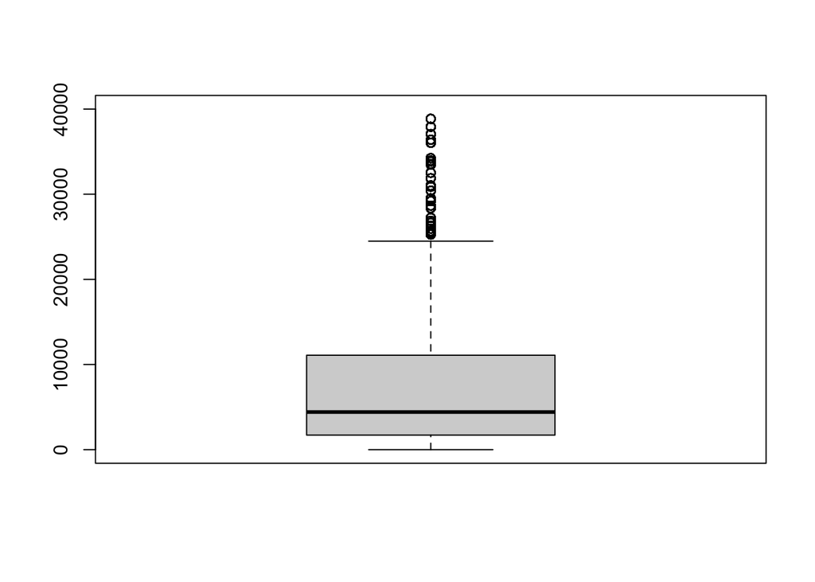

```r
boxplot(retail$MonetaryValue, ylim = c(0, 40000))
```

We remove outliers lying beyond the 5th and 95th percentiles, refining our data set and preparing it for clustering.

```r
# Calculate the 5th and 95th percentiles
lower_bound <- quantile(retail$MonetaryValue, 0.05)
upper_bound <- quantile(retail$MonetaryValue, 0.95)

# Filter the data frame to remove outliers
retail <- retail %>%
  filter(MonetaryValue >= lower_bound, MonetaryValue <= upper_bound)

# Print the filtered data frame
head(retail, 20)
```

```
##    Customer.ID Invoice StockCode                         Description Quantity
## 1        12347  549222     23076          ICE CREAM SUNDAE LIP GLOSS      240
## 2        12347  529924     20985                    HEART CALCULATOR       12
## 3        12347  581180    84625A  PINK NEW BAROQUECANDLESTICK CANDLE       24
## 4        12347  529924     72819        CUPID DESIGN SCENTED CANDLES        6
## 5        12347  581180     20719              WOODLAND CHARLOTTE BAG       10
## 6        12347  581180     23084                  RABBIT NIGHT LIGHT       24
## 7        12347  537626     22729         ALARM CLOCK BAKELIKE ORANGE        4
## 8        12347  549222     22196        SMALL HEART MEASURING SPOONS       12
## 9        12347  529924    51014C              FEATHER PEN,COAL BLACK       12
## 10       12347  529924     22331    WOODLAND PARTY BAG + STICKER SET       16
## 11       12347  529924     21372        MIRRORED WALL ART TABLE LAMP       24
## 12       12347  581180     23271 CHRISTMAS TABLE SILVER CANDLE SPIKE       16
## 13       12347  537626     22774   RED DRAWER KNOB ACRYLIC EDWARDIAN       12
## 14       12347  537626     84969  BOX OF 6 ASSORTED COLOUR TEASPOONS        6
```

[output cut: 48 more lines]

### DATA EXPLORATION

#### By country

##### By Country #Percentage of transactions per country (TOP 10)

```r
# Calculate the percentage of transactions by country
transactions_by_country <- retail %>%
  distinct(Invoice, Country) %>%
  group_by(Country) %>%
  summarise(Percentage = n_distinct(Invoice) / n_distinct(retail$Invoice) * 100)

# Select the top 10 countries
top_10_countries <- transactions_by_country %>%
  top_n(10)
```

```r
# Create the bar chart of top 10 countries
top10_countries_transactions <-  ggplot(top_10_countries, aes(x = reorder (Country,-Percentage), y = Percentage, fill = Country)) +
  geom_bar(stat = "identity") +
  labs(title = "Transactions",
       x = "Country", y = "Pct of transactions") +
  scale_fill_discrete(name = "Country") +
  theme_light()+
  theme(
    plot.title = element_text(hjust = 0.5),
    panel.grid.major = element_line(colour = "gray90"),
    legend.position = "none",
    axis.text.x = element_text(angle = 45, hjust = 1)
  )
```

##### Percentage of revenue per country (TOP 10)

```r
# Calculate the percentage of revenue by country
revenue_by_country <- retail %>%
  group_by(Country) %>%
  summarise(total_revenue = sum(MonetaryValue)) %>%
  mutate(Percentage = (total_revenue / sum(total_revenue)) * 100)

# Select the top 10 countries
top_10_countries_revenue <- revenue_by_country %>%
  top_n(10)
```

```r
#Plot
top10_countries_revenue_g <- ggplot(top_10_countries_revenue, aes(x = reorder (Country,-Percentage), y = Percentage, fill = Country)) +
  geom_bar(stat = "identity") +
  labs(title = "Revenue",
       x = "Country", y = "Pct of revenue") +
  scale_fill_discrete(name = "Country") +
  theme_light()+
  theme(
    plot.title = element_text(hjust = 0.5),
    panel.grid.major = element_line(colour = "gray90"),
    legend.position = "none",
    axis.text.x = element_text(angle = 45, hjust = 1)
  )
```

##### Graphs

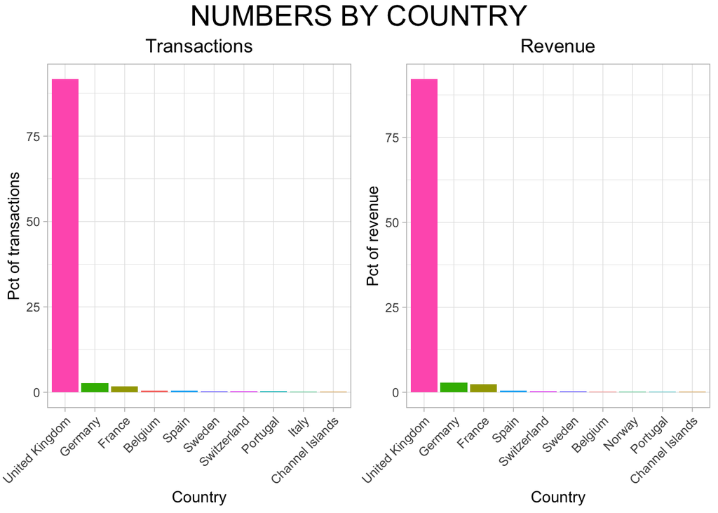

```r
# Combine the graphs into one grid
country_graphs <- grid.arrange(top10_countries_transactions,
                               top10_countries_revenue_g,
                               nrow = 1,
                               top=textGrob("NUMBERS BY COUNTRY", gp=gpar(fontsize=20)))
```

By analyzing the percentage of transactions and revenue by country, we can get valuable insights into customer behavior, market dynamics, and revenue sources. It will allow the company to identify of core markets, prioritize resource allocation, and tailor strategies to optimize customer engagement and revenue generation in each country.

#### By Year

##### Percentage of transaction by year

```r
# Extract the year from the Date column
retail <- retail %>%
  mutate(Year = format(Date, "%Y"))

# Calculate the percentage of transactions by year
transactions_by_year <- retail %>%
  distinct(Invoice, Year) %>%
  group_by(Year) %>%
  summarize(Percentage = n_distinct(Invoice) / n_distinct(retail$Invoice) * 100)

# Create the bar chart
year_transactions <-  ggplot(transactions_by_year, aes(x = Year, y = Percentage, fill = Year)) +
  geom_bar(stat = "identity") +
  labs(title = "Transactions",
       x = "Year", y = "Pct of Transactions") +
  scale_fill_discrete(name = "Year") +
  theme_light()+
  theme(
    plot.title = element_text(hjust = 0.5),
    panel.grid.major = element_line(colour = "gray90"),
    legend.position = "none",
  )
```

##### Percentage of revenue by year

```r
# Calculate the percentage of revenue by year
revenue_by_year <- retail %>%
  group_by(Year) %>%
  summarize(total_revenue = sum(MonetaryValue)) %>%
  mutate(Percentage = (total_revenue / sum(total_revenue)) * 100)

# Create the bar chart
year_revenue <- ggplot(revenue_by_year, aes(x = Year, y = Percentage, fill = Year)) +
  geom_bar(stat = "identity") +
  labs(title = "Revenue",
       x = "Year", y = "Pct of Revenue") +
  scale_fill_discrete(name = "Year") +
  theme_light()+
  theme(
    plot.title = element_text(hjust = 0.5),
    panel.grid.major = element_line(colour = "gray90"),
    legend.position = "none",
  )
```

##### Graphs

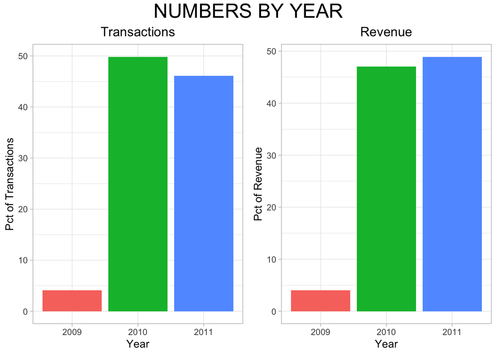

```r
# Combine the graphs into one grid
year_graphs <- grid.arrange(year_transactions,
                            year_revenue,
                            nrow = 1,
                            top=textGrob("NUMBERS BY YEAR", gp=gpar(fontsize=20)))
```

The analysis of transaction and revenue percentages by year reveals valuable insights into the company’s performance.

- In **2010**, the company experienced a si*gnificant surge in both transaction volume (49.84%) and revenue generation (47.07%).* This suggests a period of heightened customer engagement and successful conversion of transactions into revenue. This might be the cause of effectively capitalizing on market opportunities, implementing successful marketing strategies, and meeting customer demands.
- Following **2010**, the company *maintained a solid performance in* **2011**, with transaction percentages accounting for 46.09% and revenue percentages reaching 48.92%. This indicates that the company not only sustained customer engagement but also effectively converted transactions into revenue, leading to continued business growth.
- In contrast, the year **2009** contributed a relatively *lower percentage of transactions (4.08%) and revenue (4.01%).* This suggests that the company was in its early stages of operation or faced external factors that limited growth during that period. This also presents an opportunity for the company to analyze the factors contributing to the lower performance

#### By Month

##### Percentage of transactions by month

```r
# Extract the year from the Date column
retail <- retail %>%
  mutate(Month = format(Date, "%m"))

# Calculate the percentage of transactions by month
transactions_by_month <- retail %>%
  distinct(Invoice, Month) %>%
  group_by(Month) %>%
  summarize(Percentage = n_distinct(Invoice) / n_distinct(retail$Invoice) * 100)

# Create the bar chart
month_transactions <-  ggplot(transactions_by_month, aes(x = Month, y = Percentage, fill = Month)) +
  geom_bar(stat = "identity") +
  labs(title = "Transactions",
       x = "Month", y = "Pct of transactions") +
  scale_fill_discrete(name = "Month") +
  theme_light()+
  theme(
    plot.title = element_text(hjust = 0.5),
    panel.grid.major = element_line(colour = "gray90"),
    legend.position = "none",
  )
```

##### Percentage of revenue by month

```r
# Calculate the percentage of revenue by year
revenue_by_month <- retail %>%
  group_by(Month) %>%
  summarize(total_revenue = sum(MonetaryValue)) %>%
  mutate(Percentage = (total_revenue / sum(total_revenue)) * 100)

# Create the bar chart
month_revenue <- ggplot(revenue_by_month, aes(x = Month, y = Percentage, fill = Month)) +
  geom_bar(stat = "identity") +
  labs(title = "Revenue",
       x = "Month", y = "Pct of Revenue") +
  scale_fill_discrete(name = "Month") +
  theme_light()+
  theme(
    plot.title = element_text(hjust = 0.5),
    panel.grid.major = element_line(colour = "gray90"),
    legend.position = "none",
  )
```

##### Graphs

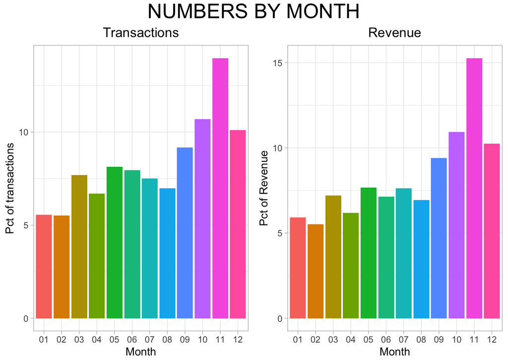

```r
# Combine the graphs into one grid
month_graphs <- grid.arrange(month_transactions,
                            month_revenue,
                            nrow = 1,
                            top=textGrob("NUMBERS BY MONTH", gp=gpar(fontsize=20)))
```

#### By Weekday

##### Percentage of transactions by weekday

```r
# Calculate the percentage of transactions by weekday
transactions_by_weekday <- retail %>%
  distinct(Invoice, Weekday) %>%
  group_by(Weekday) %>%
  summarize(Percentage = n_distinct(Invoice) / n_distinct(retail$Invoice) * 100)

# Create the bar chart
weekday_transactions <-  ggplot(transactions_by_weekday, aes(x = reorder(Weekday, -Percentage), y = Percentage, fill = Weekday)) +
  geom_bar(stat = "identity") +
  labs(title = "Transactions",
       x = "Weekday", y = "Pct of Transactions") +
  scale_fill_discrete(name = "Weekday") +
  theme_light()+
  theme(
    plot.title = element_text(hjust = 0.5),
    panel.grid.major = element_line(colour = "gray90"),
    legend.position = "none",
    axis.text.x = element_text(angle = 45, hjust = 1)
  )
```

##### Percentage of revenue by weekday

```r
# Calculate the percentage of revenue by weekday
revenue_by_weekday <- retail %>%
  group_by(Weekday) %>%
  summarize(total_revenue = sum(MonetaryValue)) %>%
  mutate(Percentage = (total_revenue / sum(total_revenue)) * 100)

# Create the bar chart
weekday_revenue <-ggplot(revenue_by_weekday, aes(x = reorder(Weekday, -Percentage), y = Percentage, fill = Weekday)) +
  geom_bar(stat = "identity") +
  labs(title = "Revenue",
       x = "Weekday", y = "Pct of Revenue") +
  scale_fill_discrete(name = "Weekday") +
  theme_light()+
  theme(
    plot.title = element_text(hjust = 0.5),
    panel.grid.major = element_line(colour = "gray90"),
    legend.position = "none",
    axis.text.x = element_text(angle = 45, hjust = 1)
  )
```

##### Graphs

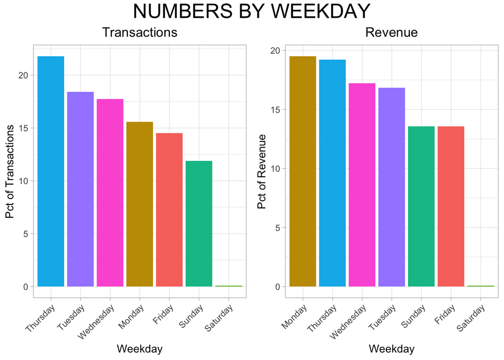

```r
# Combine the graphs into one grid
weekday_graphs <- grid.arrange(weekday_transactions,
                            weekday_revenue,
                            nrow = 1,
                            top=textGrob("NUMBERS BY WEEKDAY", gp=gpar(fontsize=20)))
```

#### By hour

##### Percentage of transactions by hour of the day

```r
# Extract the hour component from the Time column
retail$Hour <- format(retail$Time, format = "%H")

# Calculate the percentage of transactions by hour
hourly_transactions <- retail %>%
  group_by(Hour) %>%
  summarise(NumInvoices = n_distinct(Invoice)) %>%
  mutate(Percentage = NumInvoices / sum(NumInvoices) * 100)

#Graph
hour_transactions <-  ggplot(hourly_transactions, aes(x = Hour, y = Percentage)) +
  geom_line(aes(group = 1)) +
  geom_point() +
  xlab("Hour of the Day") +
  ylab("Percentage of Transactions") +
  ggtitle("Hourly Transactions") +
  theme_minimal()+
  theme(plot.title = element_text(hjust = 0.5))
```

##### Percentage of revenue by hour of the day

```r
# Calculate the percentage of revenue by hour
hourly_revenue <- retail %>%
  group_by(Hour) %>%
  summarise(TotalRevenue = sum(`MonetaryValue`)) %>%
  mutate(Percentage = TotalRevenue / sum(TotalRevenue) * 100)

#Create chart
hour_revenue <-  ggplot(hourly_revenue, aes(x = Hour, y = Percentage)) +
  geom_line(aes(group = 1)) +
  geom_point() +
  xlab("Hour of the Day") +
  ylab("Percentage of Revenue") +
  ggtitle("Hourly Revenue") +
  theme_minimal()+
  theme(plot.title = element_text(hjust = 0.5))
```

##### Graphs

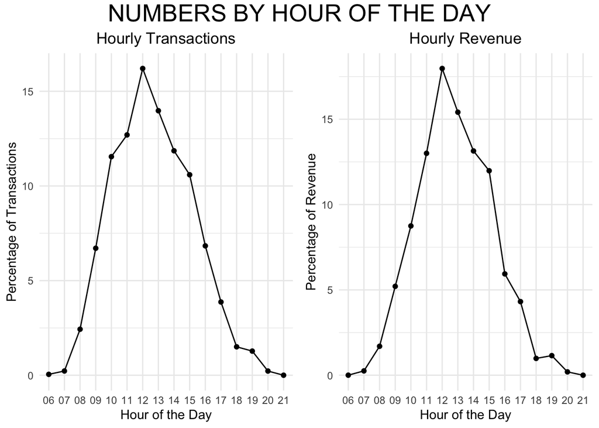

```r
# Combine the graphs into one grid
hours_graphs <- grid.arrange(hour_transactions,
                            hour_revenue,
                            nrow = 1,
                            top=textGrob("NUMBERS BY HOUR OF THE DAY", gp=gpar(fontsize=20)))
```

##### Graph (Option 2)

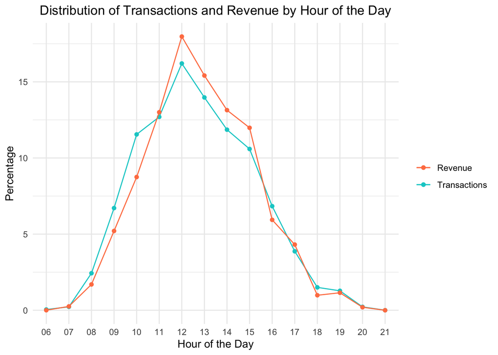

```r
ggplot() +
  geom_line(data = hourly_transactions, aes(x = Hour, y = Percentage, color = "Transactions", group = 1)) +
  geom_point(data = hourly_transactions, aes(x = Hour, y = Percentage, color = "Transactions")) +
  geom_line(data = hourly_revenue, aes(x = Hour, y = Percentage, color = "Revenue", group = 1)) +
  geom_point(data = hourly_revenue, aes(x = Hour, y = Percentage, color = "Revenue")) +
  xlab("Hour of the Day") +
  ylab("Percentage") +
  ggtitle("Distribution of Transactions and Revenue by Hour of the Day") +
  scale_color_manual(values = c("Transactions" = "cyan3", "Revenue" = "coral")) +
  theme_minimal() +
  theme(legend.title = element_blank(),
        plot.title = element_text(hjust = 0.5))
```

The analysis of transaction and revenue percentages by hour of the day reveals the following insights:

- The majority of transactions and revenue occur during business hours, particularly between 9 AM and 5 PM. This could be due to a higher percentage of customers being wholesalers or businesses.
- *The highest transaction percentages are observed between 10 AM and 2 PM, peaking at 12 PM.* These hours represent the busiest period for transactions, suggesting that customers are more active and engaged during midday.
- Revenue percentages align with transaction percentages, highlighting a positive correlation.
- Outside of regular business hours, such as in the evening and early morning, both transaction and revenue percentages decline significantly. This indicates lower customer activity and potential opportunities to explore strategies to engage customers during non-peak hours.

#### Order status

```r
# Calculate the count and percentage of cancelled and not cancelled orders
status_counts <- retail %>%
  group_by(Cancelled) %>%
  summarise(Count = n()) %>%
  mutate(Percentage = Count / sum(Count) * 100)

# Print the table
datatable(status_counts,
          caption = "ORDER STATUS",
          options = list(dom = 't', paging = FALSE, searching = FALSE))
```

|  | Cancelled | Count | Percentage |
| --- | --- | --- | --- |
| 1 | 0 | 701859 | 97.8264778319974 |
| 2 | 1 | 15594 | 2.17352216800264 |

- The majority of orders, approximately 97.83%, are not cancelled, indicating a high rate of successful transactions and customer satisfaction.
- A small percentage, approximately **2.17%, of orders are cancelled**. While this percentage is *relatively low,* it is still important for the company to monitor and address the reasons behind cancellations to minimize their occurrence and potential impact on customer experience.

### CLUSTERING

Prepare the data

```r
#Create new df with only the variables that will be useful for the clustering analysis
data_cluster <- select(retail,c(Recency,Frequency,MonetaryValue, UniqueProducts))

# Convert 'Recency' from difftime to numeric (Clustering algorithms prefer all variables to be of the same class)
data_cluster$Recency <- as.numeric(data_cluster$Recency)
```

```r
str(data_cluster)
```

```
## 'data.frame':    717453 obs. of  4 variables:
##  $ Recency       : num  402 402 402 402 402 402 402 402 402 402 ...
##  $ Frequency     : int  8 8 8 8 8 8 8 8 8 8 ...
##  $ MonetaryValue : num  4922 4922 4922 4922 4922 ...
##  $ UniqueProducts: int  126 126 126 126 126 126 126 126 126 126 ...
```

##### Scale the data

```r
data_cluster = scale(data_cluster)

#Check results
head(data_cluster)
```

```
##         Recency  Frequency MonetaryValue UniqueProducts
## [1,] -0.5739585 -0.4077032    -0.3227526     -0.4766251
## [2,] -0.5739585 -0.4077032    -0.3227526     -0.4766251
## [3,] -0.5739585 -0.4077032    -0.3227526     -0.4766251
## [4,] -0.5739585 -0.4077032    -0.3227526     -0.4766251
## [5,] -0.5739585 -0.4077032    -0.3227526     -0.4766251
## [6,] -0.5739585 -0.4077032    -0.3227526     -0.4766251
```

#### K-Means

##### Total within sum of squares Plot

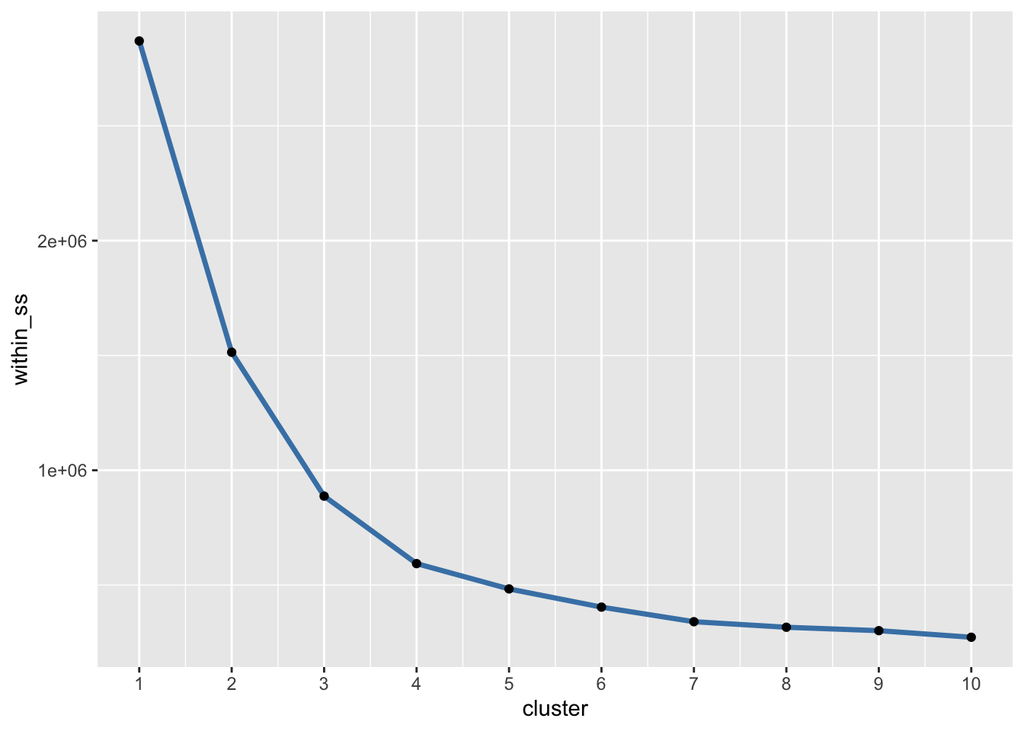

```r
within_ss = sapply(1:10,FUN = function(x){
  set.seed(617)
  kmeans(x = data_cluster,centers = x,iter.max = 1000,nstart = 25)$tot.withinss})

ggplot(data=data.frame(cluster = 1:10,within_ss),aes(x=cluster,y=within_ss))+
  geom_line(col='steelblue',size=1.2)+
  geom_point()+
  scale_x_continuous(breaks=seq(1,10,1))
```

The total within sum of square and ratio plots support a three- and four- cluster solution.

##### Ratio Plot

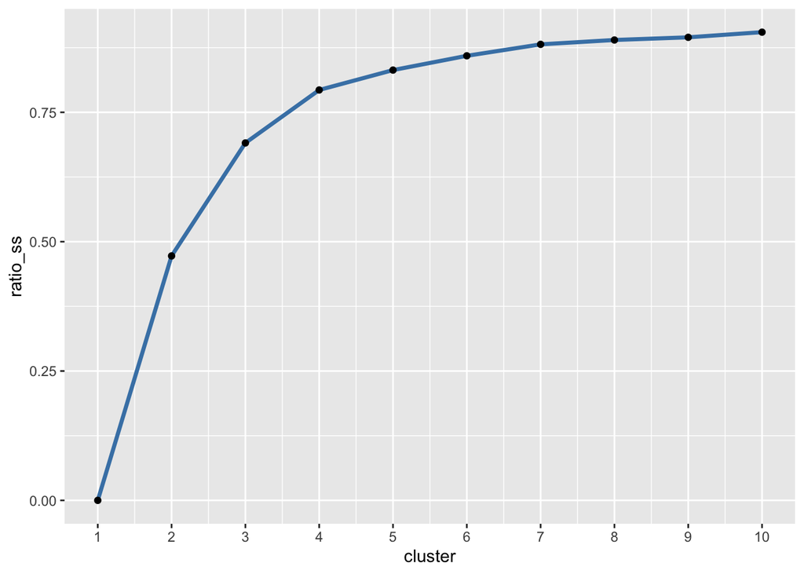

```r
ratio_ss = sapply(1:10,FUN = function(x) {
  set.seed(617)
  km = kmeans(x = data_cluster,centers = x,iter.max = 1000,nstart = 25)
  km$betweenss/km$totss} )
ggplot(data=data.frame(cluster = 1:10,ratio_ss),aes(x=cluster,y=ratio_ss))+
  geom_line(col='steelblue',size=1.2)+
  geom_point()+
  scale_x_continuous(breaks=seq(1,10,1))
```

###### How many people composed the 3 cluster solution

```r
set.seed(617)
km3 = kmeans(x = data_cluster,centers = 3,iter.max=10000,nstart=25)
k_segments3 = km3$cluster
table(k_segments3)
```

```
## k_segments3
##      1      2      3
## 232898 458755  25800
```

###### How many people composed the 4 cluster solution

```r
set.seed(617)
km4 = kmeans(x = data_cluster,centers = 4,iter.max=10000,nstart=25)
k_segments4 = km4$cluster
table(k_segments4)
```

```
## k_segments4
##      1      2      3      4
## 425068  25800 223445  43140
```

#### Visualize

3-cluster solution

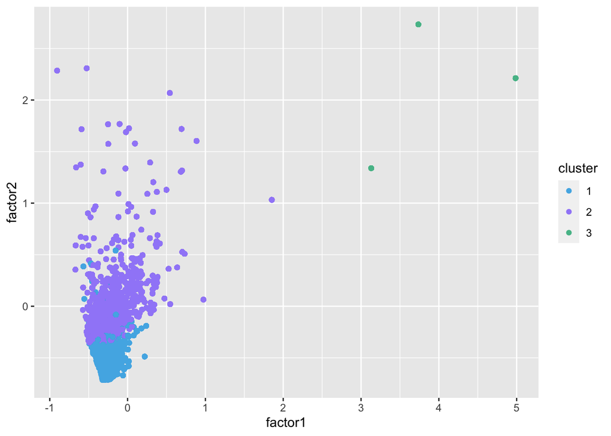

```r
temp_k3 = data.frame(cluster = factor(k_segments3),
           factor1 = fa(data_cluster,nfactors = 2,rotate = 'varimax')$scores[,1],
           factor2 = fa(data_cluster,nfactors = 2,rotate = 'varimax')$scores[,2])
ggplot(temp_k3,aes(x=factor1,y=factor2,col=cluster))+
  geom_point()+
  scale_color_manual(values = c("#52B4E6", "#A18BF8", "#56BD97"))
```

4-cluster solution

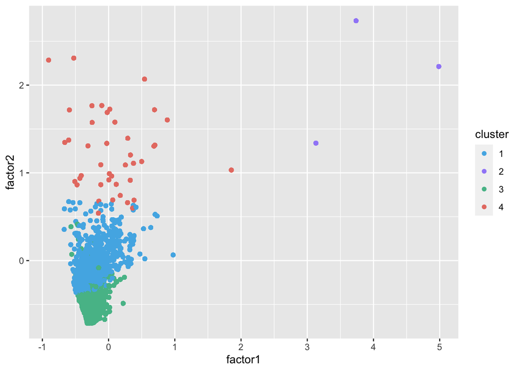

```r
# Define your desired color palette
my_colors <- c("#52B4E6", "#A18BF8", "#56BD97", "#E77D72")

#Visualize
temp_k4 = data.frame(cluster = factor(k_segments4),
           factor1 = fa(data_cluster,nfactors = 2,rotate = 'varimax')$scores[,1],
           factor2 = fa(data_cluster,nfactors = 2,rotate = 'varimax')$scores[,2])
ggplot(temp_k4,aes(x=factor1,y=factor2,col=cluster))+
  geom_point()+
  scale_color_manual(values = my_colors)
```

After analyzing the results of the K-means clustering, it has been determined that a *4-cluster solution* is the most suitable choice. This decision is primarily based on the *sizes of the clusters*. By opting for four clusters, we ensure that there are still sufficiently large groups, minimizing any potential operational challenges.

Moreover, selecting a 4-cluster solution allows us to gain an advantage by *implementing more personalized strategies* for each group. With distinct clusters, we can tailor our approach and marketing efforts to meet the specific preferences and needs of each customer segment. This personalized approach has the potential to yield higher customer satisfaction, increased engagement, and improved overall business performance.

###### Radar Chart

4-cluster solution

```r
# Create a data frame with the cluster labels and variables
cluster_data_k4 <- data.frame(cluster = factor(k_segments4),
                           Recency = retail$Recency,
                           Frequency = retail$Frequency,
                           MonetaryValue = retail$MonetaryValue,
                           UniqueProducts = retail$UniqueProducts)

# Calculate the means for each variable within each cluster
cluster_means_k4 <- aggregate(. ~ cluster, cluster_data_k4, mean, na.rm = TRUE)

print(cluster_means_k4)
```

```
##   cluster  Recency  Frequency MonetaryValue UniqueProducts
## 1       1 643.1018  22.666418      7092.512       277.7927
## 2       2 735.4898 301.066357     52386.118      1949.4648
## 3       3 258.1577   7.692058      2319.603       136.7873
## 4       4 611.2975  81.560941     40640.432       456.2195
```

Plot in radar chart

```r
# Create the cluster_means_k4 data frame
cluster_means_k4 <- data.frame(
  row.names  = (c(1, 2, 3, 4)),
  Recency = c(643.1018, 735.4898, 258.1577, 611.2975),
  Frequency = c(22.666418, 301.066357, 7.692058, 81.560941),
  MonetaryValue = c(7092.512, 52386.118, 2319.603, 40640.432),
  UniqueProducts = c(277.7927, 1949.4648, 136.7873, 456.2195)
)

# Define the variable ranges: maximum and minimum
max_min_k4 <- data.frame(Recency = c(800, 0), Frequency = c(400, 0), MonetaryValue = c(55000, 0), UniqueProducts = c(2000,0))
rownames(max_min_k4) <- c("Max", "Min")


# Bind the variable ranges to the data
df_k4 <- rbind(max_min_k4, cluster_means_k4)
df_k4
```

```
##      Recency  Frequency MonetaryValue UniqueProducts
## Max 800.0000 400.000000     55000.000      2000.0000
## Min   0.0000   0.000000         0.000         0.0000
## 1   643.1018  22.666418      7092.512       277.7927
## 2   735.4898 301.066357     52386.118      1949.4648
## 3   258.1577   7.692058      2319.603       136.7873
## 4   611.2975  81.560941     40640.432       456.2195
```

Helper function to produce a beautiful radar chart:

```r
create_beautiful_radarchart <- function(data, color = "#00AFBB",
                                        vlabels = colnames(data), vlcex = 0.6,
                                        caxislabels = NULL, title = NULL, ...){
  radarchart(
    data, axistype = 1,
    # Customize the polygon
    pcol = color, pfcol = scales::alpha(color, 0.5), plwd = 2, plty = 1,
    # Customize the grid
    cglcol = "grey", cglty = 1, cglwd = 0.8,
    # Customize the axis
    axislabcol = "transparent",
    # Variable labels
    vlcex = vlcex, vlabels = vlabels,
    caxislabels = caxislabels, title = title, ...
  )
}
```

Create separated spider charts for each cluster.

```r
# Define colors and titles
colors <- c("#52B4E6", "#A18BF8", "#56BD97", "#E77D72")
titles <- c("CLUSTER 1", "CLUSTER 2", "CLUSTER 3", "CLUSTER 4")

# Reduce plot margin using par()
op <- par(mar = c(1, 1, 1, 1))

# Set the canvas size and chart size
par(mfrow = c(1, 4), mar = c(5, 5, 4, 2))

# Set the dimensions of the PDF file
pdf("radar_charts(k4).pdf", width = 14, height = 7)

# Set the layout
par(mfrow = c(2, 2))

# Loop through each cluster and create the radar chart
for (i in 1:4) {
  create_beautiful_radarchart(data = df_k4[c(1, 2, i+2), ],
                              caxislabels = "",  # Remove caxislabels
                              color = colors[i],
                              title = titles[i])
}


# Close the PDF file
dev.off()
```

Import Plot (4 Cluster Solution)

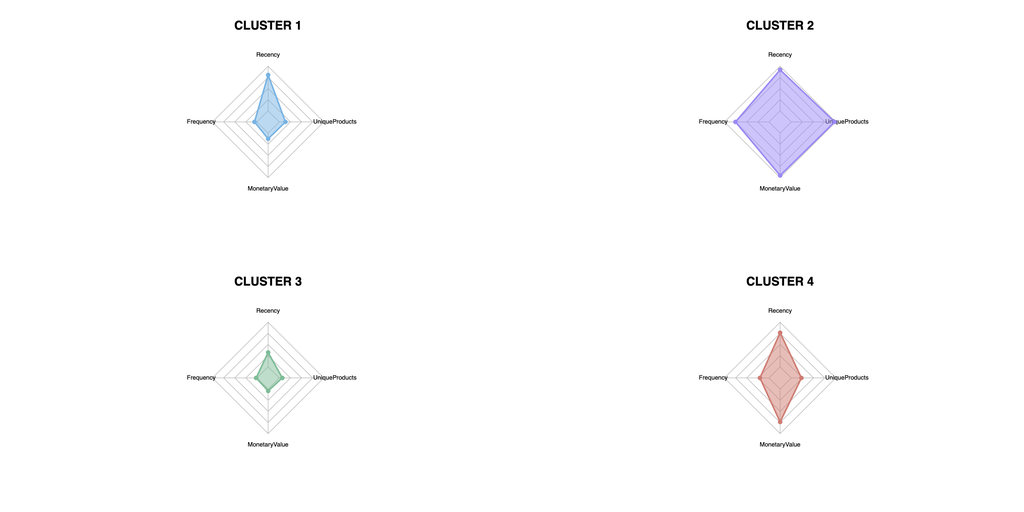

```r
knitr::include_graphics("radar_charts(k4).png")
```

#### Takeaways

Based on the previous data, here are the possible strategies for each cluster:

**CLUSTER 1 - THE NEW CUSTOMER**

These customers have not spent much but show potential for future engagement. To keep them engaged and coming back, the business can consider the following strategies:  
Introduce them to new products: Send personalized recommendations based on their preferences and past purchases.

- Offer discounts or deals: Provide special offers to incentivize repeat purchases and encourage them to explore more products.
- Implement a loyalty program: Offer rewards for their continued engagement and purchases, encouraging them to become loyal customers.
- Send targeted marketing campaigns: Use email or other communication channels to keep them informed about new products, promotions, and upcoming sales.

**CLUSTER 2 - THE LOYALIST**

These customers already engage with the company frequently and are valuable for the business. The goal is to maintain their loyalty and ensure they keep coming back. Strategies for this cluster include:

- Enhance the customer experience: Provide excellent customer service to ensure their satisfaction and address any issues promptly.
- Personalize offers and recommendations: Analyze their past purchases and preferences to tailor product suggestions and promotions specifically for them.
- Reward their loyalty: Implement an exclusive loyalty program with tiered benefits, offering discounts, early access to new products, or personalized rewards.
- Seek feedback: Regularly collect feedback to understand their needs, preferences, and areas where the business can improve.

**CLUSTER 3 - THE FORGOTTEN/UNATTENDED**

These customers have made a few purchases, but they are not engaged with the company. Strategies for this cluster may include:

- Re-engage through targeted campaigns: Send personalized emails or notifications highlighting new products, offers, or relevant updates based on their previous purchases.
- Offer incentives for re-engagement: Provide exclusive discounts or promotions to encourage them to make another purchase.
- Implement a win-back program: Design a series of targeted messages to remind them of the brand and its value, emphasizing any improvements or new features since their last interaction.
- Improve communication: Ensure that the business is actively reaching out to these customers, making them aware of ongoing promotions or relevant events.

**CLUSTER 4 - THE IRREGULAR**

These customers have spent a significant amount on a few specific products but are not regular shoppers. To encourage repeat purchases, the following strategies can be considered:

- Cross-selling and upselling: Recommend related products based on their previous purchases to increase their basket size.
- Create product bundles or promotions: Offer discounts or package deals that include the products they have previously shown interest in, along with complementary items.
- Send reminders or notifications: Notify them about restocks, limited-time offers, or promotions related to the products they have previously purchased.
- Collect feedback: Understand their reasons for irregular shopping behavior and address any concerns or barriers that may prevent them from making repeat purchases.

### MARKET BASKET ANALYSIS

#### Pre-processing

```r
# Select the necessary columns for the analysis
items <- retail[, c("Invoice", "Description")]


#Convert the Description column to character or factor type
items$Description <- as.character(items$Description)

#Remove rows with missing values in Description column
items <- items[complete.cases(items$Description), ]

head(items,20)
```

```
##    Invoice                         Description
## 1   549222          ICE CREAM SUNDAE LIP GLOSS
## 2   529924                    HEART CALCULATOR
## 3   581180  PINK NEW BAROQUECANDLESTICK CANDLE
## 4   529924        CUPID DESIGN SCENTED CANDLES
## 5   581180              WOODLAND CHARLOTTE BAG
## 6   581180                  RABBIT NIGHT LIGHT
## 7   537626         ALARM CLOCK BAKELIKE ORANGE
## 8   549222        SMALL HEART MEASURING SPOONS
## 9   529924              FEATHER PEN,COAL BLACK
## 10  529924    WOODLAND PARTY BAG + STICKER SET
## 11  529924        MIRRORED WALL ART TABLE LAMP
## 12  581180 CHRISTMAS TABLE SILVER CANDLE SPIKE
## 13  537626   RED DRAWER KNOB ACRYLIC EDWARDIAN
## 14  537626  BOX OF 6 ASSORTED COLOUR TEASPOONS
## 15  573511      MINI LIGHTS WOODLAND MUSHROOMS
## 16  529924     PINK POODLE HANGING DECORATION
## 17  537626   BLUE 3 PIECE POLKADOT CUTLERY SET
## 18  573511        AIRLINE BAG VINTAGE TOKYO 78
## 19  529924      COSY SLIPPER SHOES SMALL GREEN
## 20  529924     GREEN REGENCY TEACUP AND SAUCER
```

```r
# Convert the dataframe to a transaction object
transactions <- as(split(items$Description, items$Invoice), "transactions")
# Inspect the transactions
summary(transactions) #Look at the console for results
```

```
## transactions as itemMatrix in sparse format with
##  38986 rows (elements/itemsets/transactions) and
##  5229 columns (items) and a density of 0.003469065
##
## most frequent items:
## WHITE HANGING HEART T-LIGHT HOLDER           REGENCY CAKESTAND 3 TIER
##                               4557                               3225
##      ASSORTED COLOUR BIRD ORNAMENT            JUMBO BAG RED RETROSPOT
##                               2451                               2397
##                      PARTY BUNTING                            (Other)
##                               1932                             692634
##
## element (itemset/transaction) length distribution:
## sizes
##    1    2    3    4    5    6    7    8    9   10   11   12   13   14   15   16
## 6249 2567 1711 1274 1202 1020 1019  960 1029  928  937  899  890  890  949  918
##   17   18   19   20   21   22   23   24   25   26   27   28   29   30   31   32
##  852  834  857  808  721  645  612  535  496  485  440  424  450  397  341  311
##   33   34   35   36   37   38   39   40   41   42   43   44   45   46   47   48
##  290  282  244  251  233  217  236  233  217  180  172  164  154  148  167  142
##   49   50   51   52   53   54   55   56   57   58   59   60   61   62   63   64
##  136  142  114  114  110  109  113   90  104   86   61   87   77   65   64   73
##   65   66   67   68   69   70   71   72   73   74   75   76   77   78   79   80
##   68   55   46   55   44   56   51   34   42   45   42   32   28   33   26   26
##   81   82   83   84   85   86   87   88   89   90   91   92   93   94   95   96
##   27   28   27   34   22   19   22   25   26   23   17   18   20   12   16   14
##   97   98   99  100  101  102  103  104  105  106  107  108  109  110  111  112
##   14   19    9   23   14    4   14   12    7    7   12    6    8   11    9    5
##  113  114  115  116  117  118  119  120  121  122  123  124  125  126  127  128
##    5   11   11   15    7    6    8    5    9    9    7    4    4    4    8    2
##  129  130  131  132  133  134  135  136  137  138  139  140  141  142  143  144
##    5    3    4    6    2    4    9    5    3    4    1    1    4    2    2    1
##  145  146  147  148  149  150  151  152  153  154  155  156  157  158  161  163
##    5    2    2    3    3    1    2    1    2    3    1    1    1    1    1    1
##  164  165  167  169  170  171  174  175  176  178  180  181  182  184  187  190
##    1    3    1    1    1    2    1    1    2    1    1    2    1    2    1    1
##  192  193  195  199  204  208  210  219  220  221  228  240  249  250  259  262
##    1    1    1    1    1    1    1    2    1    1    1    1    1    1    1    1
##  271  280  333  347  352  363  375  386  419  434  439  525  529  541
##    1    1    1    1    1    1    1    1    1    1    1    1    1    1
##
##    Min. 1st Qu.  Median    Mean 3rd Qu.    Max.
##    1.00    3.00   12.00   18.14   24.00  541.00
##
## includes extended item information - examples:
##                                labels
## 1   DOORMAT UNION JACK GUNS AND ROSES
## 2            3 STRIPEY MICE FELTCRAFT
## 3       4 PURPLE FLOCK DINNER CANDLES
##
## includes extended transaction information - examples:
##   transactionID
## 1        489434
## 2        489435
## 3        489436
```

#### Explore Data

Examine individual items. Support is set to 0 so we can see all items.

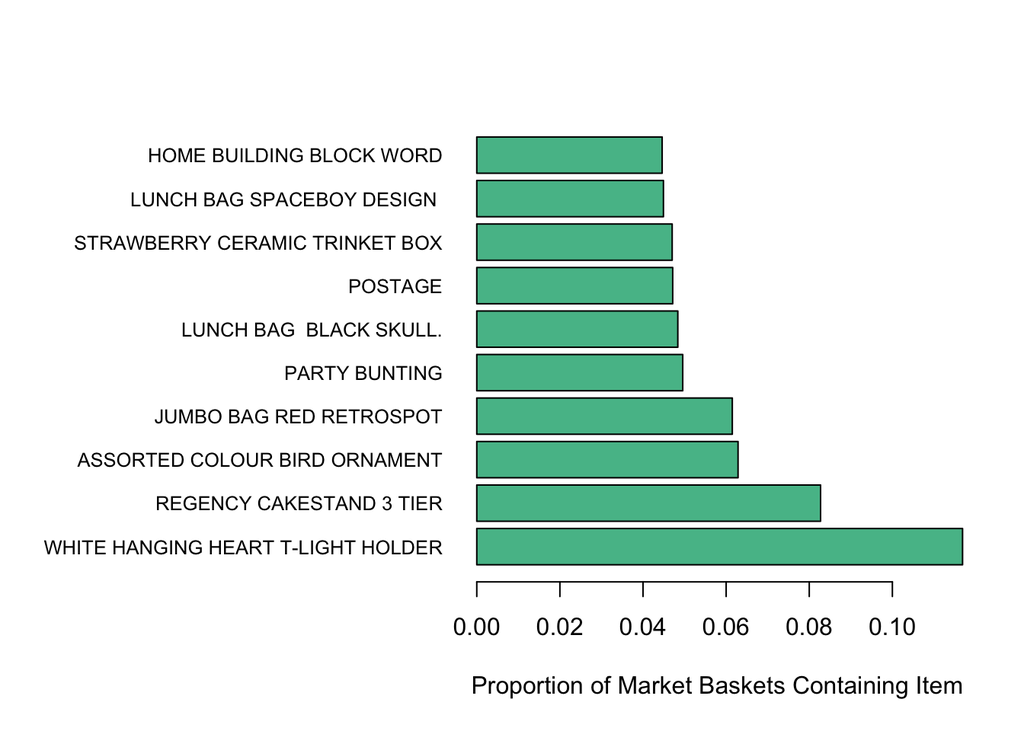

```r
itemFrequencyPlot(transactions, support = 0.0, cex.names=0.8,
                  type = "relative", horiz = TRUE, col = "#56BD97", las = 1, topN=10,
                  xlab = paste("Proportion of Market Baskets Containing Item"))
```

#### Analysis

Identify list association of rules.

```r
#We will filter rules with just two items are more actionable than ones that have many items.
rules = apriori(transactions,parameter=list(support=0.01,confidence=0.5, minlen = 2))
```

```
## Apriori
##
## Parameter specification:
##  confidence minval smax arem  aval originalSupport maxtime support minlen
##         0.5    0.1    1 none FALSE            TRUE       5    0.01      2
##  maxlen target  ext
##      10  rules TRUE
##
## Algorithmic control:
##  filter tree heap memopt load sort verbose
##     0.1 TRUE TRUE  FALSE TRUE    2    TRUE
##
## Absolute minimum support count: 389
##
## set item appearances ...[0 item(s)] done [0.00s].
## set transactions ...[5229 item(s), 38986 transaction(s)] done [0.09s].
## sorting and recoding items ... [457 item(s)] done [0.01s].
## creating transaction tree ... done [0.01s].
## checking subsets of size 1 2 3 done [0.01s].
## writing ... [65 rule(s)] done [0.00s].
## creating S4 object  ... done [0.00s].
```

```r
  #Support measures the frequency or popularity of an items in a data set. How often do A and B appear together.
  #Confidence quantifies the strength of an association rule between two items A and B." If A is already in the basket, what are the         chances the B is also added.
  #Lift values greater than 1 indicate a positive association between the two items (the occurrence of A increases the likelihood of B)
```

```r
summary(rules)
```

```
## set of 65 rules
##
## rule length distribution (lhs + rhs):sizes
##  2  3
## 60  5
##
##    Min. 1st Qu.  Median    Mean 3rd Qu.    Max.
##   2.000   2.000   2.000   2.077   2.000   3.000
##
## summary of quality measures:
##     support          confidence        coverage            lift
##  Min.   :0.01005   Min.   :0.5006   Min.   :0.01295   Min.   : 5.999
##  1st Qu.:0.01080   1st Qu.:0.5558   1st Qu.:0.01639   1st Qu.:15.196
##  Median :0.01203   Median :0.6176   Median :0.02042   Median :23.454
##  Mean   :0.01338   Mean   :0.6362   Mean   :0.02156   Mean   :26.731
##  3rd Qu.:0.01418   3rd Qu.:0.7055   3rd Qu.:0.02465   3rd Qu.:36.329
##  Max.   :0.02673   Max.   :0.8795   Max.   :0.04286   Max.   :58.314
##      count
##  Min.   : 392.0
##  1st Qu.: 421.0
##  Median : 469.0
##  Mean   : 521.5
##  3rd Qu.: 553.0
##  Max.   :1042.0
##
## mining info:
##          data ntransactions support confidence
##  transactions         38986    0.01        0.5
##                                                                                          call
##  apriori(data = transactions, parameter = list(support = 0.01, confidence = 0.5, minlen = 2))
```

The market basket analysis generated a set of **65 rules**, with the majority *(60 rules) having a length of 2, and the remaining 5 rules having a length of 3.* This indicates that most associations are between two items.

Quality Measures: The summary of quality measures provides information about the support, confidence, coverage, lift, and count for the generated rules. Here are some key observations:

- Support: The minimum support for a rule is 0.01005, indicating that the rule appears in at least 1% of the transactions.
- Confidence: The minimum confidence for a rule is 0.5006, implying that the rule is correct at least 50.06% of the time.
- Lift: The minimum lift for a rule is 5.999, indicating that the rule has 5.999 times higher probability of occurrence compared to random chance.

```r
# Sort rules by lift in descending order
sorted_rules <- sort(rules, by = "lift", decreasing = TRUE)

# Inspect the sorted rules
inspect(sorted_rules)
```

```
##      lhs                                      rhs                                      support confidence   coverage      lift count
## [1]  {POPPY'S PLAYHOUSE BEDROOM }          => {POPPY'S PLAYHOUSE KITCHEN}           0.01118350  0.8466019 0.01320987 58.313822   436
## [2]  {POPPY'S PLAYHOUSE KITCHEN}           => {POPPY'S PLAYHOUSE BEDROOM }          0.01118350  0.7703180 0.01451803 58.313822   436
## [3]  {SET/6 RED SPOTTY PAPER CUPS}         => {SET/6 RED SPOTTY PAPER PLATES}       0.01187606  0.7955326 0.01492844 48.010272   463
## [4]  {SET/6 RED SPOTTY PAPER PLATES}       => {SET/6 RED SPOTTY PAPER CUPS}         0.01187606  0.7167183 0.01657005 48.010272   463
## [5]  {KEY FOB , BACK DOOR }                => {KEY FOB , SHED}                      0.01026009  0.7352941 0.01395373 45.501867   400
## [6]  {KEY FOB , SHED}                      => {KEY FOB , BACK DOOR }                0.01026009  0.6349206 0.01615965 45.501867   400
## [7]  {WOODEN STAR CHRISTMAS SCANDINAVIAN}  => {WOODEN HEART CHRISTMAS SCANDINAVIAN} 0.01056790  0.7079038 0.01492844 43.189885   412
## [8]  {WOODEN HEART CHRISTMAS SCANDINAVIAN} => {WOODEN STAR CHRISTMAS SCANDINAVIAN}  0.01056790  0.6447574 0.01639050 43.189885   412
## [9]  {GREEN REGENCY TEACUP AND SAUCER,
##       ROSES REGENCY TEACUP AND SAUCER }    => {PINK REGENCY TEACUP AND SAUCER}      0.01197866  0.7086495 0.01690350 40.628541   467
## [10] {FELTCRAFT CUSHION RABBIT}            => {FELTCRAFT CUSHION BUTTERFLY}         0.01061920  0.6519685 0.01628790 40.154256   414
## [11] {FELTCRAFT CUSHION BUTTERFLY}         => {FELTCRAFT CUSHION RABBIT}            0.01061920  0.6540284 0.01623660 40.154256   414
## [12] {PINK REGENCY TEACUP AND SAUCER,
##       ROSES REGENCY TEACUP AND SAUCER }    => {GREEN REGENCY TEACUP AND SAUCER}     0.01197866  0.8794727 0.01362027 39.961681   467
```

[output cut: 56 more lines]

#### Visualize

Grouped matrix-based visualization.

```r
#Visualize the top 20 rules with a Grouped matrix-based visualization.
pdf("grouped_matrix-based.pdf", width = 20, height = 10)
plot(rules, method = "grouped", control = list(k = 20))
dev.off()
```

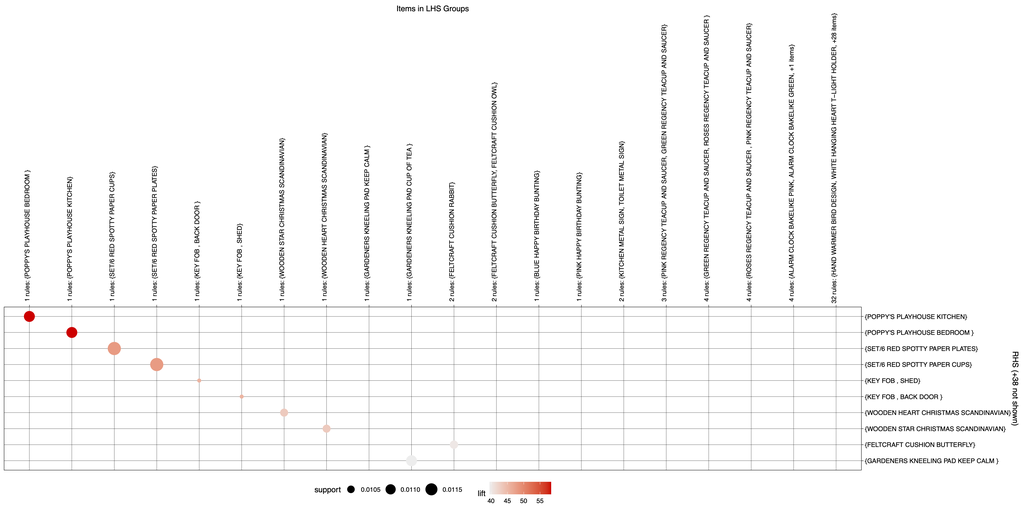

```r
#Import as PNG image
knitr::include_graphics("/Users/pilarbifaretti/Desktop/Portfolio/Online Retail II/grouped_matrix-based.png")
```

[figure not shown]

```r
#Visualize the top 20 rules with a Grouped matrix-based visualization.

parallel_coordinates <- head(rules, n = 20, by = "lift")

pdf("parallel_coordinates.pdf", width = 14, height = 10)

#Import as PNG image
knitr::include_graphics("/Users/pilarbifaretti/Desktop/Portfolio/Online Retail II/parallel_coordinates.png")
```

#### Takeaways

The retail dataset study reveals surprising patterns in client purchasing behavior. One noteworthy result is that **purchasers prefer products that compliment one other or are offered in a variety of colors**. Customers who buy the pleasant “Poppy’s Playhouse Bedroom” are more likely to buy the captivating “Poppy’s Playhouse Kitchen,” and vice versa. Moreover, customers show a tendency to purchase different kitchen accessories together, such as teacups and plates, indicating a preference for cohesive sets.

The lift values for most rules are significantly greater than 1, indicating that thes*e associations are not simply due to chance* but have a substantial impact on the likelihood of purchasing the associated items together.

**Recommendations** for the retailer based on these findings would be to consider the following strategies:

1. Cross-selling: Leverage the strong associations between products to cross-promote them on the website. For example, when a customer views or purchases a home decor item , suggest the other related items from the same category.
2. Bundling and Discounts: Consider creating bundled offers or discounts for related items to encourage customers to purchase them together.
3. Personalization: Utilize association rules to personalize product recommendations for individual customers. If a customer has shown interest in one item from a related pair, then an associated item would be recommended to increase the likelihood of a purchase.
4. Targeted Marketing: Use the associations to target specific customer segments. For instance, customers who have purchased “Green Regency Teacup and Saucer” and “Pink Regency Teacup and Saucer” together could be targeted with promotions for the “Roses Regency Teacup and Saucer.”

### CONCLUSIONS

The analysis of the Online Retail II data set has provided **valuable insights into customer behavior, market dynamics, and revenue sources for the non-store online retailer**. The main goals of the analysis were achieved through cluster analysis and market basket analysis.

Data Exploration

The exploration of the data provided a deeper understanding of customer behavior throughout the years, months, weekdays, and hours. Key insights were gained into transaction and revenue distribution, seasonal patterns, and peak activity hours. The analysis also highlighted the importance of the United Kingdom as the dominant market, with Germany and France being significant contributors to transactions and revenue.

Cluster Analysis

The use of K-means clustering resulted in a 4-cluster solution, which allowed for meaningful customer segmentation. Each cluster represents a distinct group of customers with unique characteristics and behaviors. The four identified clusters are “The New Customer,” “The Loyalist,” “The Forgotten/Unattended,” and “The Irregular.” For each cluster, specific strategies were recommended to enhance customer engagement, loyalty, and repeat purchases.

Market Basket Analysis

The market basket analysis revealed interesting product associations, showing that customers tend to buy complementary products together. Strong associations between items were identified, and lift values greater than 1 indicated significant impacts on the likelihood of purchasing associated items together. Recommendations based on these findings included cross-selling, bundling and discounts, personalized recommendations, and targeted marketing.

**FINAL RECOMMENDATIONS**

Based on the analysis, the retailer should focus on personalized strategies for each customer cluster to maximize customer satisfaction and engagement. The company should continue to nurture customer relationships in the UK market and strategically target Germany and France for further growth. Additionally, the retailer should consider adjusting inventory levels, optimizing marketing campaigns, and offering targeted promotions to capitalize on seasonal patterns and increase revenue during peak periods.

Incorporating cross-selling strategies, product bundling, and personalized product recommendations can enhance the customer experience and lead to increased revenue. Moreover, the retailer should actively seek feedback from customers to understand their preferences and continuously improve their offerings.